# Same-Day Release Policies by Patient Population

Controlled 420-background policy comparison

## Main findings

- Most policy differences were practical ties.
- Horizon flexibility was most useful for strong no-show and joint-delay profiles.
- Reservations showed their clearest value for balking-sensitive populations.
- Same-day release limited reservation waste when cancellations were higher.
- Demand and Class 1 share strongly changed policy value.

## Simulation setup

The analysis contains:

- **420 backgrounds**
- **21 behavioural profiles**
- **20 clinic contexts per profile**
- **Four policies per background**
- **Five matched seed replications per policy cell**
- **Same-day release of unused reserved slots**

### Policy parameters

| Policy parameter | Baseline | Horizon only | Reservation only | Both flexible |
| --- | --- | --- | --- | --- |
| Booking horizon (H) | Native horizon | Optimized over 2, 6, 10, 14, 18, 22 and 26 days | Native horizon | Optimized over 2, 6, 10, 14, 18, 22 and 26 days |
| Reserved slots per day (Q) | 0 | 0 | Optimized from 0 to daily capacity | Optimized from 0 to daily capacity |
| Reservation window (W) | None | None | Optimized from 1 day to the native horizon when (Q>0) | Optimized from 1 day to the selected horizon when (Q>0) |
| Unused reservation release | Not applicable | Not applicable | Released to the pooled capacity on the service day | Released to the pooled capacity on the service day |

The (Q)-(W) search used:

- Coarse (Q) increments of 5
- Fine (Q) increments of 1 near the coarse winner
- Coarse (W) increments of 2 days
- Fine (W) increments of 1 day near the coarse winner
- (Q=0) as a valid option

### Problem parameters

| Problem parameter | Values or construction | Treatment |
| --- | --- | --- |
| Demand-to-capacity ratio (`rho`) | 1.0, 1.6, 2.0, 3.0 | Varied; fully crossed with Class 1 share |
| Class 1 share | 0.1, 0.3, 0.5, 0.7, 0.9 | Varied; fully crossed with `rho` |
| Daily capacity | 30 or 50 slots | Controlled by balanced assignment; not fully crossed |
| Native booking horizon | 6, 14 or 22 days | Controlled by balanced assignment; not fully crossed |
| Class 1 arrival rate | `lambda_1 = rho × capacity × Class 1 share` | Derived |
| Class 2 arrival rate | `lambda_2 = rho × capacity × (1 − Class 1 share)` | Derived |
| No-show behaviour | See the behavioural-profile table | Targeted in no-show and joint profiles; otherwise controlled |
| Balking behaviour | See the behavioural-profile table | Targeted in balking and joint profiles; otherwise controlled |
| Cancellation probability | See the behavioural-profile table | Targeted in cancellation profiles; otherwise controlled |
| Non-target behaviour | Same value for both classes | Controlled within each profile |
| Same-day cancellation capability | Enabled | Fixed |
| Reservation release rule | Same-day release | Fixed |
| Threshold capping | Disabled | Fixed |

Capacity and native horizon were assigned deterministically:

- Capacity 30 and 50 each appeared in 10 of the 20 clinic contexts.
- Native horizons 6, 14 and 22 appeared in 7, 7 and 6 contexts.
- Each demand-share pair received one capacity-horizon combination.
- The six possible capacity-horizon combinations were not all tested within every demand-share pair.

### Numerical behavioural profiles

A delay rule is written as:

`(threshold in days, probability at or below threshold, probability above threshold)`

Lower thresholds and higher probabilities indicate greater sensitivity.

| Behavioural family | Class 2 reference | Class 2 values | Class 1: same | Class 1: mild | Class 1: strong |
| --- | --- | --- | --- | --- | --- |
| No-show | Low | (20, 5%, 10%) | (20, 5%, 10%) | (14, 10%, 20%) | (7, 20%, 30%) |
| No-show | Moderate | (14, 10%, 20%) | (14, 10%, 20%) | (7, 20%, 30%) | (4, 30%, 40%) |
| Balking | Low | (22, 5%, 10%) | (22, 5%, 10%) | (16, 10%, 20%) | (9, 20%, 30%) |
| Balking | Moderate | (16, 10%, 20%) | (16, 10%, 20%) | (9, 20%, 30%) | (5, 30%, 40%) |
| Cancellation | Low | 10% | 10% | 20% | 30% |
| Joint: no-show / balking | Low | (20, 5%, 10%) / (22, 5%, 10%) | Same as Class 2 | (14, 10%, 20%) / (16, 10%, 20%) | (7, 20%, 30%) / (9, 20%, 30%) |
| Joint: no-show / balking | Moderate | (14, 10%, 20%) / (16, 10%, 20%) | Same as Class 2 | (7, 20%, 30%) / (9, 20%, 30%) | (4, 30%, 40%) / (5, 30%, 40%) |

### Non-target behaviour held fixed

| Targeted behavioural family | Behaviour held fixed for both classes |
| --- | --- |
| No-show sensitivity | Balking = (22 days, 10%, 20%); cancellation = 20% |
| Balking sensitivity | No-show = (4 days, 5%, 10%); cancellation = 20% |
| Cancellation propensity | Balking = (16 days, 10%, 20%); no-show = (14 days, 10%, 20%) |
| Joint delay sensitivity | Cancellation = 20%; no-show and balking are both targeted |

“Same” means that the two classes have identical targeted behaviour.

All non-target behavioural parameters are also identical between classes.

Class 1 share is not a behavioural profile:

- It is the proportion of arrivals belonging to Class 1.
- It is varied within every behavioural profile.
- The 21 profiles do not count Class 1 share as an additional profile.

### Matched seeds and paired confidence intervals

Each policy cell was simulated with five seed values.

- The same seed identifiers were used for the policies compared within a background.
- The policies can follow different queue paths after their decisions diverge.
- The comparison still matches Policy A seed 1 with Policy B seed 1, and so on.

For each matched seed:

> **Seed-level policy difference = Policy A outcome − Policy B outcome**

The paired 95% confidence interval was constructed as follows:

- Calculate the five matched seed differences.
- Resample those five differences with replacement.
- Calculate a mean difference for each resample.
- Repeat 2,000 times.
- Use the 2.5th and 97.5th percentiles as the interval endpoints.

It is called **paired** because the resampling uses within-seed policy differences.

Pairing removes variation shared by the two runs and usually gives a cleaner policy comparison.

A change below **0.005**, or 0.5 percentage points, is treated as a practical tie.

## Overall four-policy comparison

### How to read the figure

- Each panel represents one behavioural characteristic.
- The top-left panel represents **no-show sensitivity**.
- It combines six no-show profiles and 20 clinic contexts per profile.
- Each point is the median policy gain across those 120 backgrounds.
- Gain is measured against the baseline from the **same background**.
- The vertical range is the interquartile range.
- The outcome is overall clinic utilization, not Class 1 utilization alone.
- The dashed line marks a gain of **0.5 percentage points**.

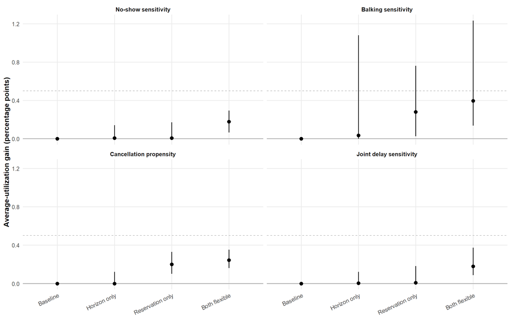

Figure 1: Median average-utilization gain relative to the same background’s baseline. Intervals show the interquartile range, not a confidence interval. All panels use the same y-axis.

### Baseline utilization

Table 1: Baseline average utilization by behavioural family.

| Behavioural family | Backgrounds | Median baseline utilization | Interquartile range |
| --- | --- | --- | --- |
| No-show sensitivity | 120 | 87.0% | 81.0%–90.8% |
| Balking sensitivity | 120 | 93.8% | 92.2%–95.0% |
| Cancellation propensity | 60 | 89.9% | 86.3%–90.0% |
| Joint delay sensitivity | 120 | 88.2% | 81.2%–91.1% |

### Why are the median gains small?

- Baseline utilization was already high in many backgrounds.
- Many low-demand and symmetric-profile backgrounds had almost no recoverable utilization loss.
- The median combines contexts where the policy helped with contexts where it did not.
- Class 1 sometimes represented only 10% or 30% of arrivals.
- A large Class 1 improvement can therefore produce a small change in overall utilization.
- Reservation policies often redistributed service between classes rather than creating many additional completed appointments.

Joint sensitivity does not imply an additive gain:

- Balking and no-show are competing outcomes.
- A patient who rejects an offered delay cannot later no-show for that appointment.
- Shortening the horizon can address both mechanisms, but it cannot recover the same patient twice.
- The median also includes same, mild and strong contrasts under both Class 2 references.
- Some individual joint-sensitivity backgrounds had gains above one percentage point.
- The median across the entire family remained below one percentage point.

### How often was the gain clear?

The next figure compares each active policy directly with baseline.

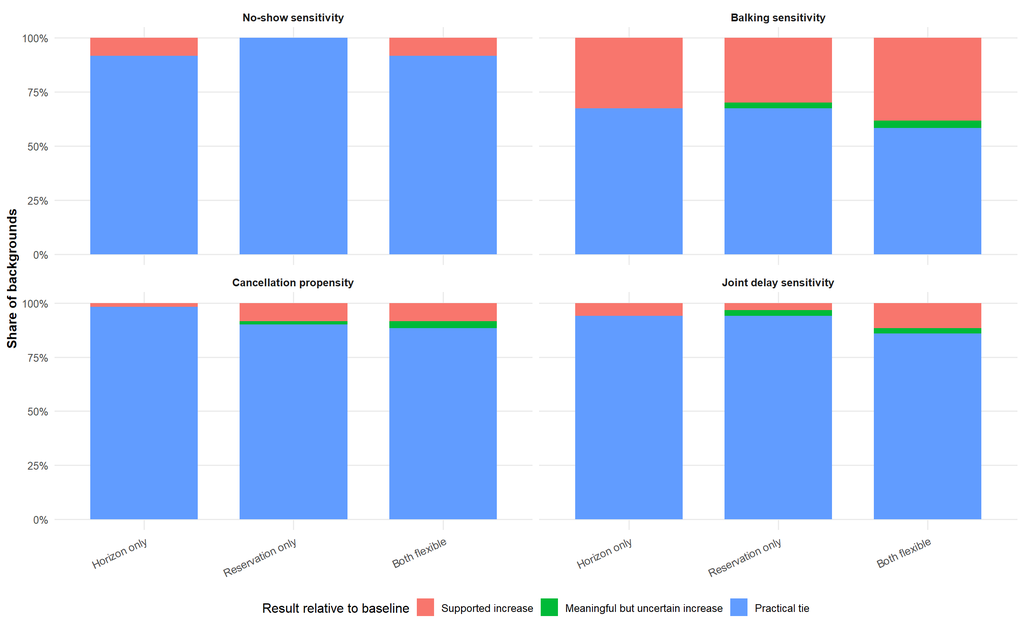

Figure 2: Evidence classification for average-utilization changes relative to baseline. Each bar sums to 100% of backgrounds within a behavioural characteristic and policy.

The categories answer different questions:

- **Supported increase**
  - Mean gain is at least 0.005.
  - The 95% interval defined above is above zero.
  - The gain is both practically meaningful and statistically supported.
- **Meaningful but uncertain increase**
  - Mean gain is at least 0.005.
  - The confidence interval still includes zero.
  - More replication may be needed.
- **Practical tie**
  - The absolute mean difference is below 0.005.
  - The difference is too small to treat as operationally important.
  - Statistical significance is not used to promote a very small effect.

This figure conveys **how consistently** a policy helped across backgrounds.

It does not convey the size of the gain. The preceding figure shows magnitude.

### How to read the profile figures

The next four figures use the same summary structure:

- Each point is the median across **20 clinic contexts**.
- A point is specific to one Class 2 reference, one contrast level and one policy.
- Those 20 contexts vary demand, Class 1 share, capacity and native horizon.
- The vertical line is the **interquartile range** across the 20 contexts.
- It is not a confidence interval.

## No-show sensitivity

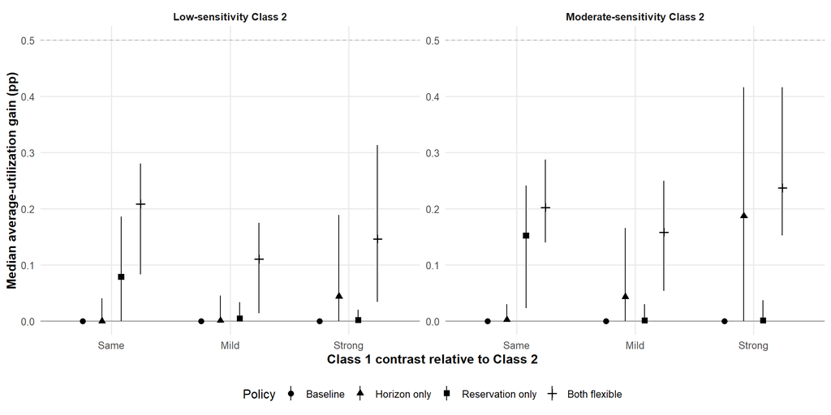

Figure 3: Median policy gain across 20 clinic contexts for each no-show reference and contrast. Lines show interquartile ranges.

- Under the **low Class 2 reference**, policy gains remained small.
- Under the **moderate reference**, strong Class 1 sensitivity increased the value of shorter horizons.
- In the moderate/strong profile:
  - Horizon only averaged about **0.50 pp** above baseline.
  - Both flexible averaged about **0.55 pp**.
  - Reservation only averaged about **0.05 pp**.
- Both flexible often selected (Q=0) in the strong profiles.
- Main implication: **shorter horizons addressed the no-show mechanism more directly than reservations.**

**Tip**

**Why can reservations affect no-show outcomes?**

- A reservation does not change either class’s no-show rule.
- It can give Class 1 access to a nearer appointment.
- If the new delay moves from above the no-show threshold to at or below it, the assigned no-show probability falls from the high value to the low value.
- If the delay remains on the same side of the threshold, the assigned probability does not change.
- The realized no-show rate can still move irregularly because the policy changes which patients obtain appointments.

**Note**

**The “same” profiles are negative controls.**

- Class 1 and Class 2 have identical cancellation, balking and no-show parameters.
- Reservation-only median gains were about **0.08 pp** under the low reference.
- They were about **0.15 pp** under the moderate reference.
- All 40 reservation-only comparisons with baseline were practical ties.
- These small positive points should not be treated as meaningful evidence of a reservation benefit.
- Finite-run variation and selecting the best (Q)-(W) cell from many candidates can move the selected point estimate slightly above zero.

## Balking sensitivity

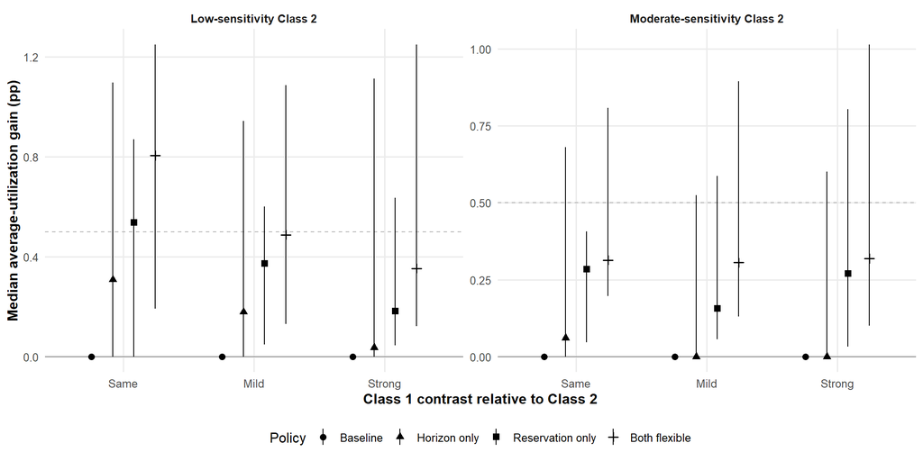

Figure 4: Median policy gain across 20 clinic contexts for each balking reference and contrast. Lines show interquartile ranges.

## Cancellation propensity

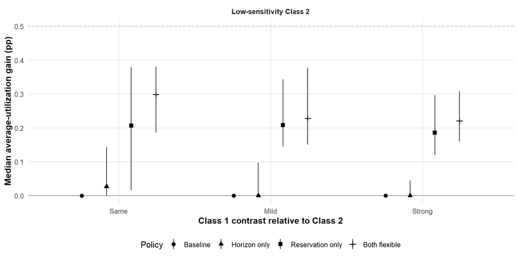

Figure 5: Median policy gain across 20 clinic contexts as Class 1 cancellation probability increases. Lines show interquartile ranges.

- Same-day release prevented a broad utilization penalty from unused reservations.
- Reservation only averaged approximately:
  - **0.31 pp** when cancellation rates were equal.
  - **0.25 pp** under the mild contrast.
  - **0.22 pp** under the strong contrast.
- Both flexible followed the same pattern.
- Higher cancellation reduced reservation value modestly.
- It did not make reservation policies generally worse than baseline.

## Joint delay sensitivity

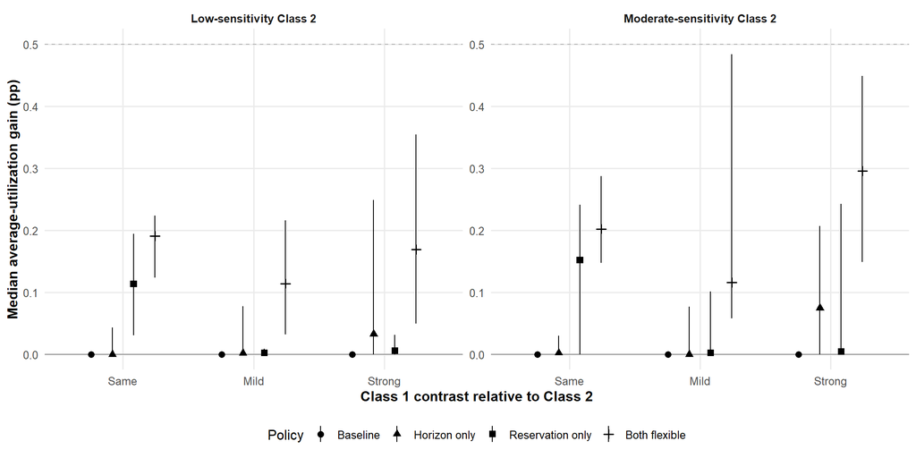

Figure 6: Median policy gain across 20 clinic contexts for each joint-sensitivity reference and contrast. Lines show interquartile ranges.

### Why are most effects close to zero?

Table 2: Baseline delay exposure and policy gains in the joint-sensitivity profiles.

| Class 2 reference | Class 1 contrast | Median baseline Class 1 offered delay | Class 1 no-show / balk threshold | Median horizon-only gain | Median both-flexible gain | Both-flexible contexts ≥0.5 pp |
| --- | --- | --- | --- | --- | --- | --- |
| Low-sensitivity Class 2 | Same | 2.59 days | 20 / 22 days | 0.00 pp | 0.19 pp | 3 of 20 |
| Low-sensitivity Class 2 | Mild | 2.45 days | 14 / 16 days | 0.00 pp | 0.11 pp | 3 of 20 |
| Low-sensitivity Class 2 | Strong | 2.16 days | 7 / 9 days | 0.03 pp | 0.17 pp | 3 of 20 |
| Moderate-sensitivity Class 2 | Same | 2.31 days | 14 / 16 days | 0.00 pp | 0.20 pp | 0 of 20 |
| Moderate-sensitivity Class 2 | Mild | 2.01 days | 7 / 9 days | 0.00 pp | 0.12 pp | 4 of 20 |
| Moderate-sensitivity Class 2 | Strong | 1.67 days | 4 / 5 days | 0.07 pp | 0.30 pp | 4 of 20 |

- Most baseline offers were already shorter than the Class 1 thresholds.
- The policies therefore changed only the tail of long-delay offers.
- In the strongest moderate profile:
  - No-show probability is still 30% at short delays.
  - Balking probability is still 30% at short delays.
  - Moving an offer below the threshold changes 40% to 30%; it does not reduce the probability to zero.
- Balking and no-show are competing outcomes.
  - A patient who balks never reaches the no-show stage.
  - The two potential improvements cannot simply be added.
- Overall utilization counts completed slots across both classes.
  - Avoiding a Class 1 balk may change who receives a slot without increasing the number of completed slots.
  - A utilization gain appears only when the policy prevents a slot from ultimately going unused.
- Large gains were concentrated in a minority of congested contexts.
- When more than half of the 20 context-level gains are very small, the median is also very small.

The clearest response occurred in the moderate/strong profile.

- Horizon flexibility shortened the delay distribution.
- Reservations added value only in selected contexts.
- Both flexible combined those mechanisms.
- The result was context-specific rather than universal.

## Priority-group share

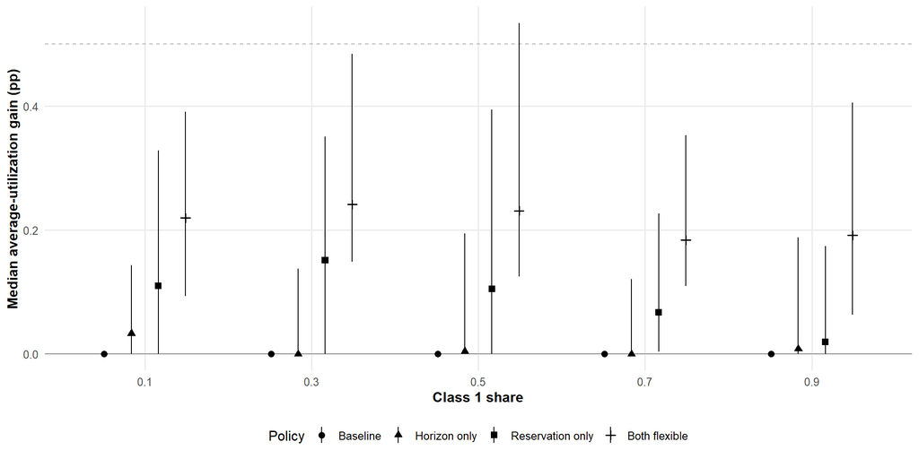

Figure 7: Four-policy comparison by Class 1 share. Points show median gains; intervals show the interquartile range across the 21 patient profiles and four demand levels.

- Reservation only was most useful at Class 1 shares of **0.1–0.5**.
- Its mean gain fell to about **0.11 pp** at a Class 1 share of 0.9.
- Horizon-only value did not fall in the same way.
- A large Class 1 population already occupies much of the pooled capacity.
- Additional priority protection then provides less incremental value.

## Clinic context

The next figure shows where each active policy improved utilization.

- Each cell is a grouped median.
- It aggregates over patient profiles, capacities and native horizons.
- It should be read as a pattern map, not as a controlled one-variable trend.

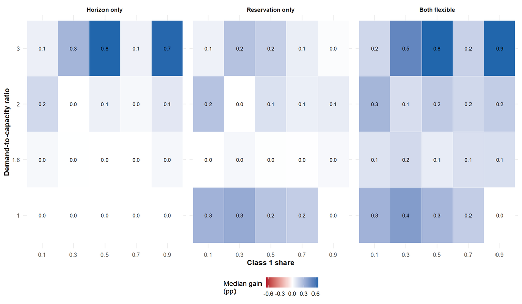

Figure 8: Median average-utilization gain by demand-to-capacity ratio, Class 1 share and active policy.

- Policy value was generally low under light demand.
- Differences became more visible under congestion.
- Reservation value depended strongly on the size of Class 1.
- Both flexible was most useful where horizon and reservation mechanisms both remained active.

## Effects on Class 1 and Class 2

Patient-group effects remain comparisons with baseline.

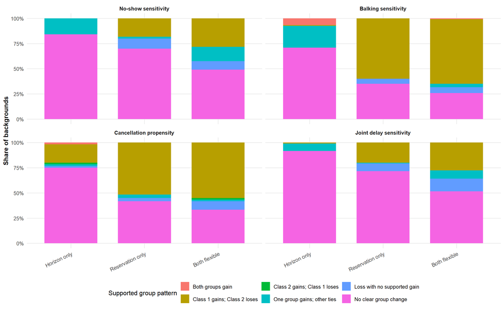

Figure 9: Confidence-supported Class 1 and Class 2 served-rate patterns for each active policy compared with baseline.

- Horizon only usually left both groups tied.
- Reservation policies often increased Class 1 served rate while reducing Class 2 served rate.
- This pattern was strongest in balking and symmetric-reference profiles.
- An average-utilization gain should not be described as a gain shared by both groups.

“Loss with no supported gain” combines:

- Class 1 loses while Class 2 ties.
- Class 2 loses while Class 1 ties.
- Both groups lose.

It excludes explicit gain-loss trade-offs.

## Selected policy parameters

### Booking horizon

The figure includes the two policies that optimize (H).

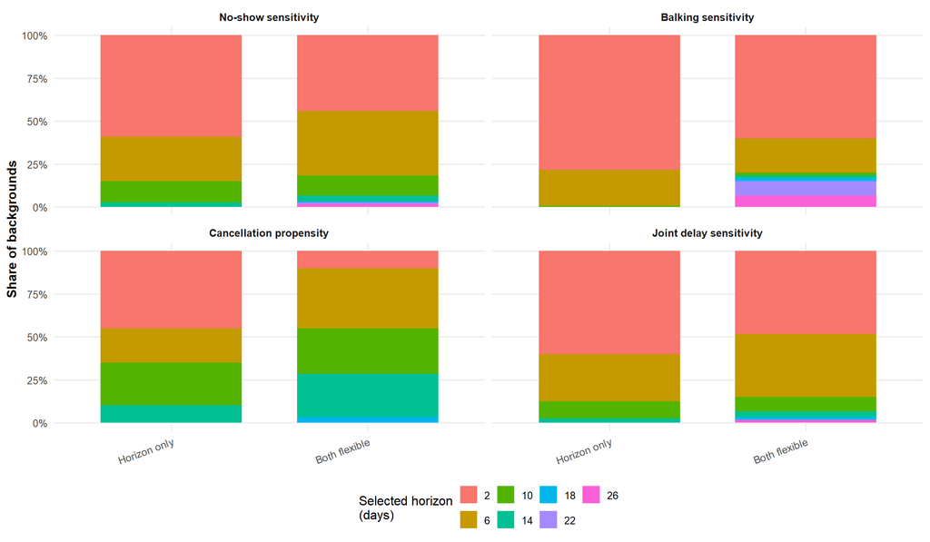

Figure 10: Distribution of selected booking horizons for horizon only and both flexible.

- Short horizons dominated no-show and joint-delay profiles.
- Balking profiles also commonly selected two days.
- Cancellation profiles retained more medium-length horizons.
- The result reflects the discrete candidate grid.

### Reservation quantity and window

The figure reports the optimized (Q) and (W) values defined in the policy-parameter table.

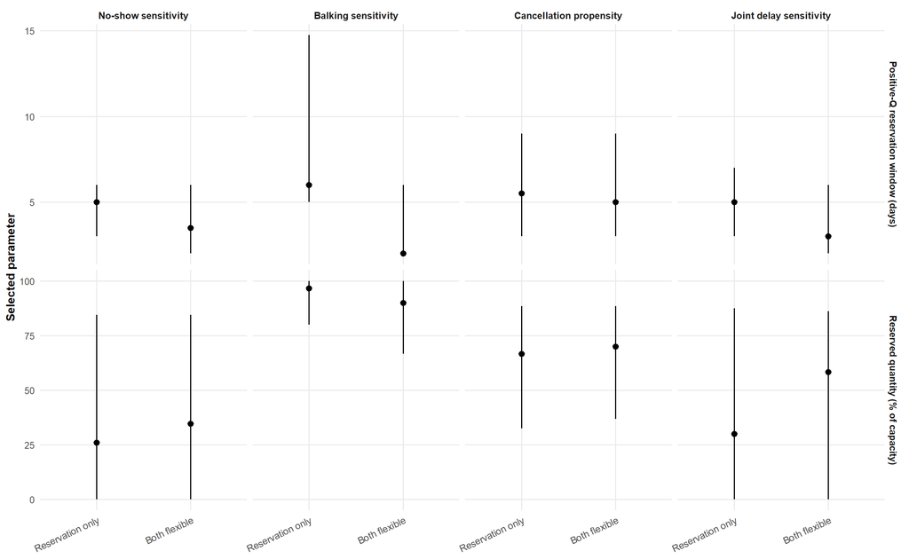

Figure 11: Selected reservation quantity and window for reservation only and both flexible. Points show medians; intervals show interquartile ranges.

- Balking profiles selected the largest reservations.
- Strong no-show and joint profiles often selected small (Q) or no reservation.
- Reservation windows were usually short when the selected horizon was short.
- (Q), window and horizon should be interpreted jointly.

## Priority-weighted served rate

The secondary objective is:

> **Priority-weighted served rate = (2 × Class 1 served rate + Class 2 served rate) ÷ 3**

Class 1 receives twice the policy weight of Class 2.

The code calls this metric `weighted_utilization`.

### What changed when the optimization objective changed?

Table 3: Effect of switching from average-utilization-optimal to priority-weighted-optimal policy cells.

| Policy | Backgrounds | Same policy cell | Median average-utilization change | Median weighted-served-rate change | Median Class 1 served-rate change | Median Class 2 served-rate change |
| --- | --- | --- | --- | --- | --- | --- |
| Baseline | 420 | 100.0% | 0.00 pp | 0.00 pp | 0.00 pp | 0.00 pp |
| Horizon only | 420 | 71.7% | 0.00 pp | 0.00 pp | 0.00 pp | 0.00 pp |
| Reservation only | 420 | 17.9% | -0.17 pp | 0.45 pp | 0.16 pp | 0.00 pp |
| Both flexible | 420 | 10.0% | -0.21 pp | 0.64 pp | 0.37 pp | -0.02 pp |

- Many backgrounds selected the same policy cell under both objectives.
- Where selections changed:
  - Class 1 served rate generally increased.
  - Class 2 served rate often decreased.
  - Average utilization sometimes fell.
- The weighted objective changes **who is served**, not only how much capacity is used.

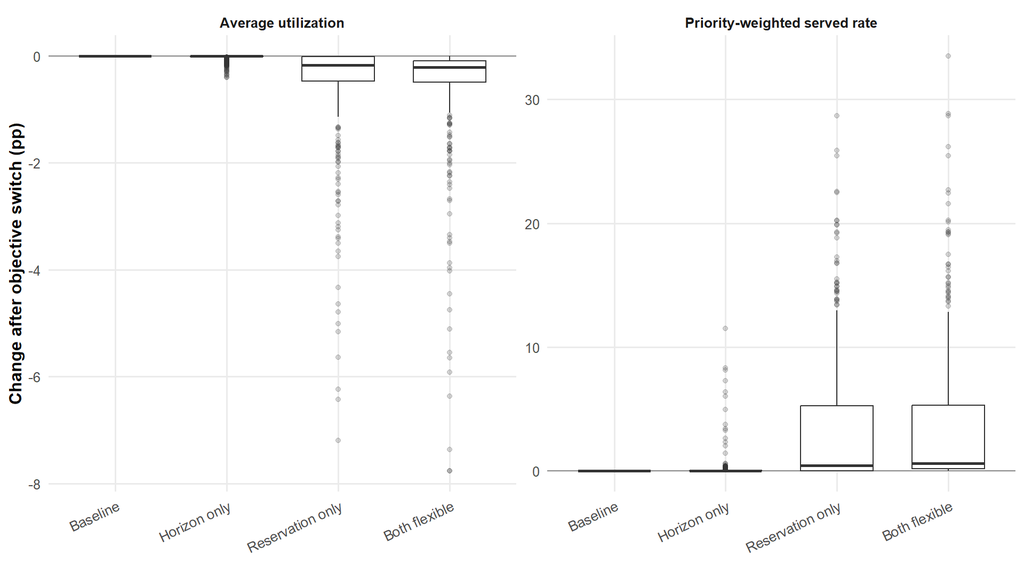

Figure 12: Average-utilization and priority-weighted-served-rate changes when switching to the priority-weighted-optimal policy cell.

## Conclusions

| Patient characteristic | Main result | Most relevant comparison |
| --- | --- | --- |
| More no-show sensitive | Horizon flexibility was the main useful mechanism | Horizon only vs both flexible |
| More balking sensitive | Reservations showed their strongest value | Reservation only vs horizon only |
| More cancellation prone | Day-of release limited reservation waste | Reservation only vs baseline |
| Jointly delay sensitive | Strong moderate-reference profiles favoured short horizons | Horizon only vs both flexible |
| Priority-group share | Reservation value declined when Class 1 was already very large | Reservation only across shares |

### What the results support

- Retain all four policy regimes.
- Retain same-day release only.
- Retain the same, mild and strong contrasts.
- Fully cross capacity and native horizon in the confirmatory run.
- Preserve the full Class 1 share range.
- Use this report structure for the final document.
- Treat practical ties as findings, not failures to select a winner.

### What requires confirmation

- Exact effect sizes.
- Capacity-specific conclusions.
- Native-horizon-specific conclusions.
- Fine interactions among profile, demand and share.
- Confirmatory statements about patient-group trade-offs.